# LT7: Latent Growth Curve Modelling

# Preliminaries

```r
library(lme4)
library(lavaan)
library(interactions)
library(tidyverse)
library(sjmisc)
library(semPlot)
```

# Introduction

Latent growth curve (LGC) models are in a sense, just a different form of the longitudinal multilevel model we looked at before reading week. In some ways they are more flexible, mostly because they are conducted in the structural equation modeling framework that allows for indirect, and other more complicated process models. Mainly, though, their main application is to developmental research where people are measured over a considerable amount of time and their trajectories of change are the dependent variables of interest.

LGC models are a very popular SEM technique in the psychological and behavioral sciences, so it makes sense to become familiar with them. To best understand a growth curve model, I still think its instructive to see it from the multilevel model framework, where things are mostly interpretable from what you know about random intercepts and slope trajectories. We will do that here. First looking at addressing LT5’s research question using multilevel modelling and then doing the same analysis with LGC modeling.

## Random effects

As a reminded of why we need this type of analysis: often data is clustered (e.g. students within schools or observations for individuals over time). The general linear model assumes independent observations, and in these situations we definitely do not have that. This is massive problem for estimates, as we saw in LT5.

One very popular way to deal with clustering are a class of models called multilevel models. They are some times called mixed models because there is a mixture of fixed effects and random effects. The fixed effects are the regression coefficients one has in standard modeling approaches. We saw how these work and are applied in LT5.

The random effects are especially important because they allow each cluster to have its own unique intercept and slope in addition to the overall fixed intercept and slope. The random effect fro any cluster is simply the cluster’s intercept and slope deviation from the overall intercept and slopes.

## Fixed and Random Effects in Longitudinal Multilevel Modelling

As we’ve seen with our work on structural equation modeling, the latent variables capture common variance in a set of correlated items, usually with a mean, and some standard deviation. Well this is also what random effects are in mixed models (i.e., variance in a set of correlated intercepts or slopes), and it’s through this that we can start to get a sense of random effects as latent variables.

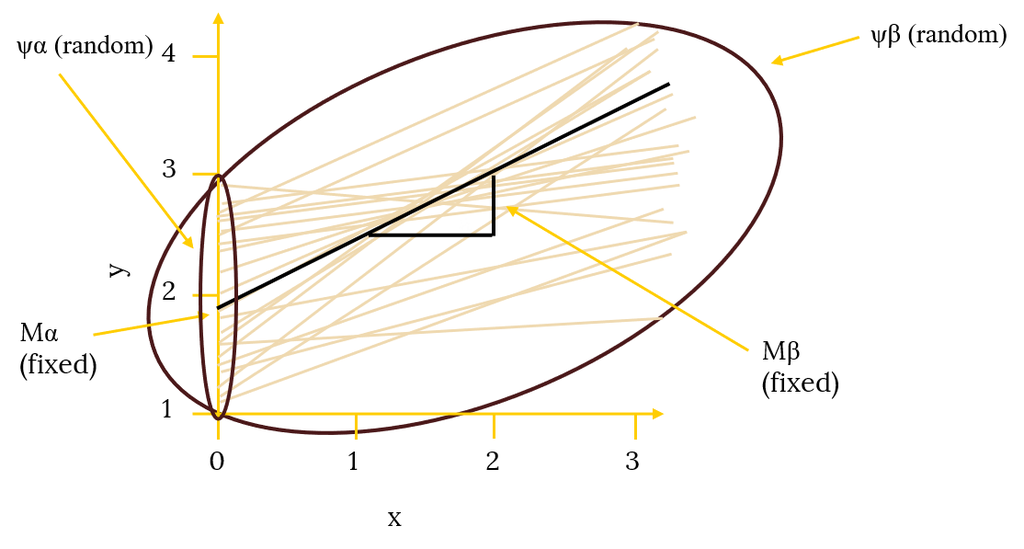

*Fixed and Random Effects in MLM*

We saw in the multilevel modeling framework that the multilevel equation for this set of effects can be expressed as:

Yti = Ma + (MB + WBi)*time + Wai + eti

Where Ma is the fixed intercept, MB is the fixed slope, WB is the random slope variance, Wa is the random intercept variance, and Y is the outcome variable for individual i at time point t. e is simply the error left over once the multilevel model is subtracted out (i.e., the error in simple ANOVA).

## Fixed and Random Effects in Structural Equation Modelling

Rather than express this model in notation form, we can also express it in latent variable form, as we might do in SEM. Lets have a look at that:

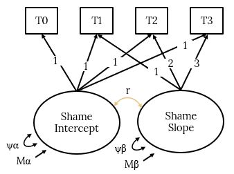

*Fixed and Random Effects in LGCM*

To all intents and purposes, this model is exactly the same as the multilevel model we have just expressed in notional format above. Just this time, the intercepts and slopes are represented by latent variables. We have a latent variable representing the random intercepts and a latent variable representing the random slopes. All loadings for the intercept latent variable are fixed at 1 so that the intercept latent variable has a mean that is the mean of the first time point (Ma). This is the fixed effect for the intercept. The intercept latent variable also has a variance that is the variability around the mean of the first time point (Wa). This is the random effect for the intercept.

The loadings for the slope latent variable are arbitrary, but should accurately reflect the time spacing, and typically, just like in the multilevel model, it is good to start at zero, so that the zero (the intercept) is the mean of the first time point. Hence, there is no loading for T0 because the T0 loading would be zero. Every loading for each time point thereafter is 1, 2, 3 and so on for a linear trajectory (we could take the square of these time points for a quadratic trend, for example, but we will stick with linear trajectories for now). In this way, the slope factor is simply the regression of time on our outcome variable (in this example, shame). The slope latent variable mean being the mean slope or trajectory of time (MB). This the fixed effect of the slope. The slope latent variable variance being the variability in the trajectories (WB).

The cool thing about modeling longitudinal trajectories in this way is that we can add latent variable predictors to explain latent variable variance in the intercept or slopes. In this way, we are modeling relationships in the absence of error and we know that is crucially important for regression.

Okay lets run this LGC with the same data we looked at in LT5.

# Longitudinal Data: Time Points Nested Within People

Recall from LT5 that the data we worked with for the analysis of longitudinal data is the stress data from Ram et al (2012). This is a classic diary design, whereby the researchers were interested to know the effects of personalty of daily levels of stress. The citation for the work is here:

Ram, N., Conroy, D. E., Pincus, A. L., Hyde, A. L., & Molloy, L. E. (2012). Tethering theory to method: Using measures of intraindividual variability to operationalize individuals’ dynamic characteristics. In G. Hancock & J. Harring (Eds.), Advances in longitudinal methods in the social and behavioral sciences (pp. 81-110). New York: Information Age.

As we saw in LT5, longitudinal data is a special case of nested data where time points are nested within people. In this case, the data Ram collected was from a diary study of workers in a big tech firm. Once a day for eight days, researchers measured employees’ levels of stress and negative affect (this is why it is called a diary study, participants typically complete a daily diary).

At the end of the study, they took one measure of neuroticism. In this way, the researchers have data at two-levels. At level two, they had between person differences in neuroticism (i.e., how people differ from the sample mean in terms of their neuroticism). At level one, they had within-person differences in stress and negative affect (i.e., how people differ from their own mean stress and negative affect on a particular day).

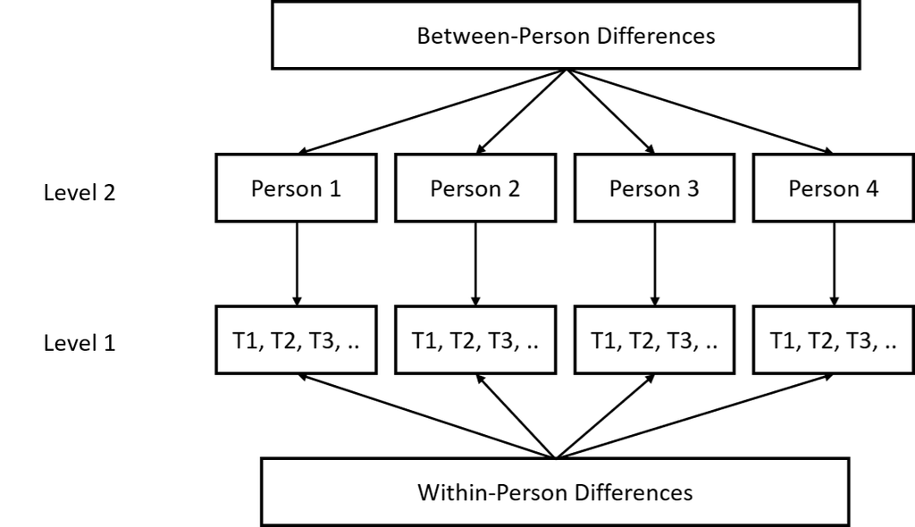

*A Two-Level Nested Longitudinal Data-Structure*

The researchers were interested to know whether neuroticism in the workplace predicted the change trajectories of stress over the period of study

To address this question with LGC we need to create our growth curve model of stress and then see whether neuroticism explains variance in the slope trajectories.

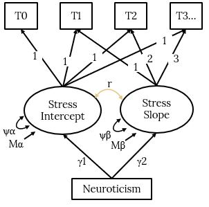

*A LGCM of Stress with Neuroticism Predicting the Stress Intercepts and Slopes*

## The Data

As always, let’s first load in the data here:

```r
stress <- read_csv("C:/Users/CURRANT/Dropbox/Work/LSE/PB230/LT7/Workshop/stress.csv")
head(stress, 16)
```

| id | day | negaff | stress | neurotic | stress_personmean | negaff_personmean | neurotic_gmc | stress_gmc | stress_pmc | negaff_pmc |
| --- | --- | --- | --- | --- | --- | --- | --- | --- | --- | --- |
| 101 | 0 | 3.00 | 1.50 | 2 | 1.06250 | 1.50000 | 0.9815789 | -0.3330326 | 0.43750 | 1.50000 |
| 101 | 1 | 2.30 | 1.25 | 2 | 1.06250 | 1.50000 | 0.9815789 | -0.3330326 | 0.18750 | 0.80000 |
| 101 | 2 | 1.00 | 0.50 | 2 | 1.06250 | 1.50000 | 0.9815789 | -0.3330326 | -0.56250 | -0.50000 |
| 101 | 3 | 1.30 | 1.00 | 2 | 1.06250 | 1.50000 | 0.9815789 | -0.3330326 | -0.06250 | -0.20000 |
| 101 | 4 | 1.10 | 1.25 | 2 | 1.06250 | 1.50000 | 0.9815789 | -0.3330326 | 0.18750 | -0.40000 |
| 101 | 5 | 1.00 | 1.25 | 2 | 1.06250 | 1.50000 | 0.9815789 | -0.3330326 | 0.18750 | -0.50000 |
| 101 | 6 | 1.20 | 0.50 | 2 | 1.06250 | 1.50000 | 0.9815789 | -0.3330326 | -0.56250 | -0.30000 |
| 101 | 7 | 1.10 | 1.25 | 2 | 1.06250 | 1.50000 | 0.9815789 | -0.3330326 | 0.18750 | -0.40000 |
| 102 | 0 | 1.40 | 0.50 | 2 | 0.78125 | 2.21875 | 0.9815789 | -0.6142826 | -0.28125 | -0.81875 |
| 102 | 1 | 1.60 | 0.00 | 2 | 0.78125 | 2.21875 | 0.9815789 | -0.6142826 | -0.78125 | -0.61875 |

[output cut: 6 more lines]

## Estimating the Model Using MLM

Let’s estimate this as a multilevel model first using the lme4 package like last week. See if you can match the parameters from our simulated data to the output.

First just the stress trajectory model with the first time point centered day variable. This is equivalent to the growth curve model. Essentially what we are doing here is examining the mean (fixed) trajectory of stress across the study, and the person-to-person variability (random) around that fixed effect. Is stress changing and do different people change in different ways?

```r
time.stress.fit <- lmer(formula = stress ~ 1 + day + (1 + day|id), REML=FALSE, data=stress)
summary(time.stress.fit)
```

```
Linear mixed model fit by maximum likelihood  ['lmerMod']
Formula: stress ~ 1 + day + (1 + day | id)
   Data: stress

     AIC      BIC   logLik deviance df.resid
  2602.4   2634.1  -1295.2   2590.4     1439

Scaled residuals:
    Min      1Q  Median      3Q     Max
-3.1112 -0.6479 -0.0737  0.5605  3.9987

Random effects:
 Groups   Name        Variance Std.Dev. Corr
 id       (Intercept) 0.174765 0.41805
          day         0.002812 0.05303  -0.14
 Residual             0.264434 0.51423
Number of obs: 1445, groups:  id, 190

Fixed effects:
            Estimate Std. Error t value
(Intercept) 1.386688   0.039095  35.470
day         0.001260   0.007091   0.178

Correlation of Fixed Effects:
    (Intr)
day -0.493
optimizer (nloptwrap) convergence code: 0 (OK)
Model failed to converge with max|grad| = 0.00345471 (tol = 0.002, component 1)
```

```r
confint(time.stress.fit, method="boot", nsim=100)
```

```
Computing bootstrap confidence intervals ...

1 warning(s): Model failed to converge with max|grad| = 0.0024367 (tol = 0.002, component 1)
```

```
                  2.5 %     97.5 %
.sig01       0.33076795 0.49725054
.sig02      -0.45476531 0.45618029
.sig03       0.02497412 0.07113472
.sigma       0.49353463 0.53655129
(Intercept)  1.30749060 1.45389642
day         -0.01477013 0.01990288
```

We saw that the slopes for stress were essentially flat according to the fixed effect (MB = .001), but there was significant person-to-person variability around that mean trajectory (WB = .05, 95% Ci = .02, .07). This was our justification for throwing neuroticism in the model as a between-person predictor of this variance.

Let’s run that model now with neuroticism interacting with day to predict the random slopes of stress:

```r
time.stress.fit2 <- lmer(formula = stress ~ 1 + day + neurotic_gmc + day*neurotic_gmc + (1 + day|id), data=stress)
summary(time.stress.fit2)
```

```
Linear mixed model fit by REML ['lmerMod']
Formula: stress ~ 1 + day + neurotic_gmc + day * neurotic_gmc + (1 + day |      id)
   Data: stress

REML criterion at convergence: 2599.3

Scaled residuals:
    Min      1Q  Median      3Q     Max
-3.1029 -0.6566 -0.0703  0.5673  4.0427

Random effects:
 Groups   Name        Variance Std.Dev. Corr
 id       (Intercept) 0.152930 0.39106
          day         0.002681 0.05178  -0.05
 Residual             0.264449 0.51425
Number of obs: 1445, groups:  id, 190

Fixed effects:
                  Estimate Std. Error t value
(Intercept)       1.386468   0.037591  36.883
day               0.001229   0.007044   0.175
neurotic_gmc     -0.165306   0.039405  -4.195
day:neurotic_gmc  0.015582   0.007372   2.114

Correlation of Fixed Effects:
            (Intr) day    nrtc_g
day         -0.474
neurotc_gmc  0.000  0.002
dy:nrtc_gmc  0.002 -0.019 -0.474
```

```r
confint(time.stress.fit2, method="boot", nsim=100)
```

```
Computing bootstrap confidence intervals ...

1 message(s): boundary (singular) fit: see help('isSingular')
5 warning(s): Model failed to converge with max|grad| = 0.00213632 (tol = 0.002, component 1) (and others)
```

```
                       2.5 %      97.5 %
.sig01            0.31638370  0.46964171
.sig02           -0.41101370  0.49630076
.sig03            0.02703897  0.06577960
.sigma            0.49138648  0.53398236
(Intercept)       1.30941824  1.45493041
day              -0.01260108  0.01533488
neurotic_gmc     -0.23783656 -0.08883729
day:neurotic_gmc  0.00100930  0.03511950
```

```
JOHNSON-NEYMAN INTERVAL

When neurotic_gmc is OUTSIDE the interval [-3.15, 1.79], the slope of day is p < .05.

Note: The range of observed values of neurotic_gmc is [-2.02, 1.98]
```

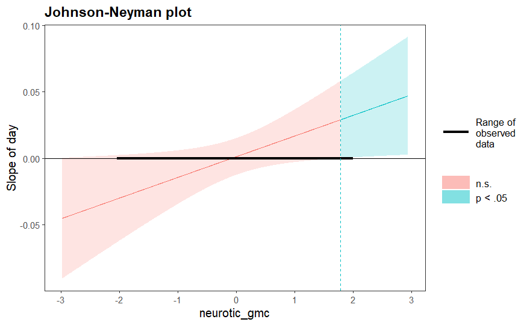

```r
johnson_neyman(model=time.stress.fit2, pred=day, modx=neurotic_gmc)
```

To show that the trajectories of stress were positive (i.e., stress increased over time) among people with higher levels of neuroticism.

Let’s now do this analysis using latent growth curve modeling.

## Doing Latent Growth Curve Analysis

As we have been doing for latent variable analysis, we’ll use lavaan to conduct LGC modeling, but now the code will look a bit strange compared to what we’re used to because we have to fix the factor loadings to specific values in order to make it work.

This also leads to non-standard output relative to other SEM models, as there is nothing to estimate for the many fixed parameters.

Specifically, we’ll have a latent variable representing the random intercepts, as well as one representing the random slopes. All loadings for the intercept factor are 1. The loadings for the effect of time run from 0 to 7, just like in the multilevel model.

## Data Structure

As can probably be guessed, our data needs to be in wide format to contain the time points as measured variables. Here, each row represents a person and we have separate columns for each time point of the target variable, as opposed to the long format we used in the previous multilevel model. We can use the spread function from tidyr to help with that.

```r
stress_wide <- stress %>%
  dplyr::select(id,day,stress,neurotic) %>%
  spread(day, stress) %>%
  rename_at(vars(-id), function(x) paste0('y', x))
head(stress_wide)
```

| id | yneurotic | y0 | y1 | y2 | y3 | y4 | y5 | y6 | y7 | y<NA> |
| --- | --- | --- | --- | --- | --- | --- | --- | --- | --- | --- |
| 101 | 2.0 | 1.50 | 1.25 | 0.50 | 1.00 | 1.25 | 1.25 | 0.50 | 1.25 | NA |
| 102 | 2.0 | 0.50 | 0.00 | 0.00 | 2.25 | 0.00 | 0.25 | 1.25 | 2.00 | NA |
| 103 | 2.5 | 1.25 | NA | NA | 1.00 | 1.25 | 0.75 | 2.00 | 1.25 | NA |
| 104 | 2.5 | 1.50 | 2.25 | 1.75 | 1.50 | 2.25 | 1.75 | 1.75 | 1.75 | NA |
| 105 | 3.5 | 1.50 | 1.50 | 1.00 | 1.25 | 2.75 | 2.50 | 1.75 | 1.75 | NA |
| 106 | 1.5 | 0.75 | 0.75 | 2.25 | 1.75 | 0.00 | 1.50 | 2.00 | 0.00 | NA |

## Building the LGC Model for Stress

Now we’re ready to run the LGC model. This is essentially the same model as the first multilevel model tested above. It asks: Is stress changing and do different people change in different ways? Only this time, we are capturing the fixed and random effects with latent variables.

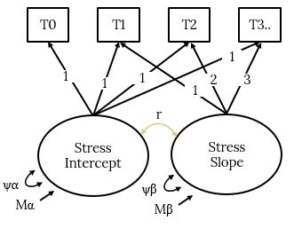

*LGCM of Stress*

When building the model, we will use the typical “=~” command to stipulate our latent variables. To give our time points their specific factor loadings, we will use “*“. But otherwise, we are just building a latent variable model, just like we have been doing in the SEM content. Lets build that model now, specifying the unique factor loadings we want for each time point on each of the intercept and slope latent variables:

```r
lgc.model <- "
    # intercept and slope with fixed coefficients
    intercept =~ 1*y0 + 1*y1 + 1*y2 + 1*y3 + 1*y4 + 1*y5 + 1*y6 + 1*y7
    slope =~ 0*y0 + 1*y1 + 2*y2 + 3*y3 + 4*y4 + 5*y5 + 6*y6 + 7*y7
"
```

## Fitting the LGCM

Note that lavaan has a specific function, growth, to use for these models. It doesn’t spare us any effort for the model coding (as above), but does make it unnecessary to set various things with the sem function:

```r
lgc.fit <- growth(lgc.model, data=stress_wide)
summary(lgc.fit, fit.measures=TRUE, standardized=TRUE)
```

```
lavaan 0.6.13 ended normally after 37 iterations

  Estimator                                         ML
  Optimization method                           NLMINB
  Number of model parameters                        13

                                                  Used       Total
  Number of observations                           159         191

Model Test User Model:

  Test statistic                                59.157
  Degrees of freedom                                31
  P-value (Chi-square)                           0.002

Model Test Baseline Model:

  Test statistic                               454.707
  Degrees of freedom                                28
  P-value                                        0.000

User Model versus Baseline Model:

  Comparative Fit Index (CFI)                    0.934
  Tucker-Lewis Index (TLI)                       0.940

Loglikelihood and Information Criteria:

  Loglikelihood user model (H0)              -1125.019
  Loglikelihood unrestricted model (H1)      -1095.441

  Akaike (AIC)                                2276.039
  Bayesian (BIC)                              2315.935
  Sample-size adjusted Bayesian (SABIC)       2274.782

Root Mean Square Error of Approximation:

  RMSEA                                          0.076
  90 Percent confidence interval - lower         0.046
  90 Percent confidence interval - upper         0.105
```

[output cut: 49 more lines]

```
    intercept         1.360    0.043   31.507    0.000    3.130    3.130
    slope             0.004    0.008    0.508    0.612    0.069    0.069

Variances:
                   Estimate  Std.Err  z-value  P(>|z|)   Std.lv  Std.all
   .y0                0.264    0.038    7.023    0.000    0.264    0.583
   .y1                0.277    0.036    7.659    0.000    0.277    0.601
   .y2                0.213    0.028    7.634    0.000    0.213    0.535
   .y3                0.278    0.035    8.038    0.000    0.278    0.590
   .y4                0.269    0.034    7.967    0.000    0.269    0.565
   .y5                0.255    0.033    7.728    0.000    0.255    0.529
   .y6                0.236    0.033    7.232    0.000    0.236    0.482
   .y7                0.256    0.038    6.754    0.000    0.256    0.473
    intercept         0.189    0.034    5.534    0.000    1.000    1.000
    slope             0.003    0.001    2.798    0.005    1.000    1.000
```

Most of the output is blank, which is needless clutter, but we do get the same five parameter values we are interested in.

Start with the ‘intercepts’:

It might be odd to call your fixed effects ‘intercepts’, but that is where lavaan prints the fixed effects for our intercepts and slopes. This makes sense if we are thinking of it as a multilevel model as depicted previously, where we actually broke out the random effects as a separate model. The estimates here for the fixed intercept (1.360) and fixed slope (.004) are more or less the same as our multilevel model model estimates (the trivial differences are due to different estimation approaches). We can also see that, just like our multilevel model, the mean (fixed) slope is not different from zero (i.e., p > .05) indicating that the average trajectory for stress is pretty much flat.

Now let’s look at the variance estimates:

The estimation of residual variance for each time point in the LGC is the variance in the differences between observed time point stress scores and the model predicted stress score for that measurement occasion. We could fix them to be identical here, or conversely allow them to be estimated in the multilevel model framework (multilevel models by default assume the same variance for each time point). Thats another reasons why the results are not identical, by the way.

The main thing to worry about here, though, is the variance of the intercepts and slopes. There are the random effects for the model. Just like in the multilevel model, we can see that the variance of the intercepts (.189) and, importantly, the slopes (.003) are greater than zero (i.e., p < .05). So even though the average stress trajectory is flat, there is significant variability around that average.

The covariance is the relationship between the random intercept and random slope, just like in the multilevel model.

We also have model fit indexes that are interpreted in exactly the same way we have been doing to date for SEM. We have CFI = .93, TLI .94, RMSEA = .08, and SRMR = .08. Thats pretty good! If there was some missfit here, it might be that we need to remove the intercept or slope factor (if no variance) or perhaps model the trajectories using quadratic or cubic terms. None of these are needed here though.

Given we have substantial variance in the random intercepts and slopes within out LGC model, we should add neuroticism to ascertain whether i can explain this variance.

## Adding a Categorical Predictor to the LGC Model

In explaining intercept and slope variance in a LGC model, we can add either categorical or continuous predictors. And these predictors can be observed or latent variables. This flexibility is what gives LGC modeling its advantage over multilevel modeling.

Lets begin with a categorical predictor. Adding a categorical variable would allow for different trajectories of stress across different groups of neuroticism. To begin with, lets create a categorical neuroticism variable, which does a simple median split such that people with neuroticism scores above the median (i.e., > 3) are coded 1, and those below the median (i.e., < 3) are coded 0.

```r
stress_wide <- dicho(stress_wide, yneurotic, dich.by = 3)
```

We now have a new variable, yneurotic_d which contains high and low scores on the neuroticism scale. When we regress this variable on our latent intercept and slope variables from the stress LGC model, we split the variance in stress intercepts and slopes by high and low neuroticism:

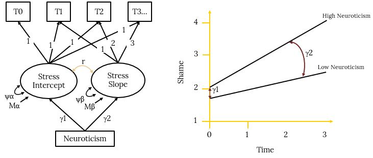

*LGCM of Stress with Categorical Predictor*

All we do to add this predictor to the model is regress it on the intercept and slope latent variables using ~. Simple!

```r
lgc.cat.model <- "
    # intercept and slope with fixed coefficients
    intercept =~ 1*y0 + 1*y1 + 1*y2 + 1*y3 + 1*y4 + 1*y5 + 1*y6 + 1*y7
    slope =~ 0*y0 + 1*y1 + 2*y2 + 3*y3 + 4*y4 + 5*y5 + 6*y6 + 7*y7
    # regress categorcial predictor on the slopes and intercepts
    intercept ~ yneurotic_d
    slope ~ yneurotic_d
"
```

## Adding a Continuous Predictor to the LGC Model

If you cast your mind back to last year when we split off continuous variables, we saw that doing so was a pretty bad idea because we are shrinking the variance in our x variable and thereby reducing the amount of variance we could potentially explain in y. For this reason, it is always better to use the full range of a continuous variable. So lets now look to see if our continuous neuroticism variable can explain variability in the latent stress intercept and slope variables from the LGC model. In this way, we can ascertain whether the trajectory slopes of stress differ across the full range of neuroticism.

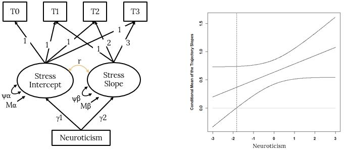

*LGCM of Stress with Continuous Predictor*

For this model we simply swap out yneurotic_d from the last model and replace it with yneurotic. Let’s build that model now:

```r
lgc.con.model <- "
    # intercept and slope with fixed coefficients
    intercept =~ 1*y0 + 1*y1 + 1*y2 + 1*y3 + 1*y4 + 1*y5 + 1*y6 + 1*y7
    slope =~ 0*y0 + 1*y1 + 2*y2 + 3*y3 + 4*y4 + 5*y5 + 6*y6 + 7*y7
    # regress continuous predictor on the slopes and intercepts
    intercept ~ yneurotic
    slope ~ yneurotic
"
```

```r
lgc.con.fit <- growth(lgc.con.model, data=stress_wide, se = "bootstrap", bootstrap = 100)
summary(lgc.con.fit, fit.measures=TRUE, standardized=TRUE)
parameterestimates(lgc.con.fit, boot.ci.type = "perc", standardized = TRUE)
```

[output not shown]

We can see that the regression of stress intercepts on neuroticism is .16 and this is a significant effect according the the 95% bootstrap confidence interval (95% Ci = .08, .24). The interpretation of this regression is that for every one unit increase in neuroticism there is a .16 unit increase in the stress starting point (i.e., time point 0). Interesting, again, but what we really want to know is whether the trajectories of stress differ across the range of neuroticism.

To answer that question we need to look to the regression of stress slopes on neuroticism. Here we have an estimate of -.02 and this is not a significant effect according the the 95% bootstrap confidence interval (95% Ci = -.03, .00001). The interpretation of this regression is that for every one unit increase in neuroticism the trajectory slopes of stress decrease by .02. However, this is not a significant decrease. Unlike the multilevel model, the growth curve analysis suggests that neuroticism does not impact on the trajectory slopes of stress.

We can visualize this model using SEM plot:

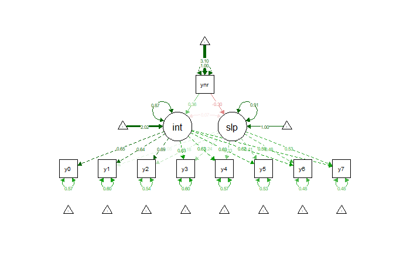

```r
semPaths(lgc.con.fit, "std")
```

## Adding a Continuous Latent Predictor to the LGC Model

By adding the measured neurotic variables to the LGCM of stress (continuous or categorical), we are simply conducting an analysis that is, to all intents and purposes, the same as multilevel modeling. We are also, importantly, using predictor variables that contain measurement error. We know this is problematic for estimates.

The major advantage of the LGCM approach is that we can add latent predictors which, as we know, are measured without error. Unfortunately, the Ram et al stress data set does not contain any item level data - just the averaged measures. No problem, we can simply simulate three correlated variables and merge them to our stress_wide dataset. Let’s quickly do that now:

```r
require(MASS)
out <- mvrnorm(191, mu = c(0,0,0), Sigma = matrix(c(1,0.65,0.65,0.65,1,0.65,0.65,0.65,1), ncol = 3),
               empirical = TRUE)
out <- as.data.frame(out)
stress_wide$v1 <- out$V1
stress_wide$v2 <- out$V2
stress_wide$v3 <- out$V3
head(stress_wide)
```

Great, we now have 3 new random correlated variables, v1, v2, and v3, in the stress_wide dataset. Let’s say for the sake our our example they are the neuroticism items. Remember, they are random, so we should not expect them to be correlated with stress. This example is simply to show you how the analysis is done and the interpretation of the output.

When a latent variable predictor is in the model, the LGCM looks like below, with the predictor represented by a latent variable that is the common variance of its items (i.e., measured without error).

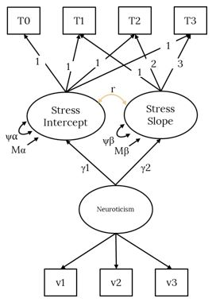

*LGCM of Stress with Latent Variable Predictor*

## Build the LGCM model with Latent Predictor

All we do to add our latent predictor to the LGCM model is create it as a new latent variable using =~ and then regress it on the intercept and slope latent variables using ~. Simple!

```r
lgc.lat.model <- "
    # intercept and slope with fixed coefficients
    intercept =~ 1*y0 + 1*y1 + 1*y2 + 1*y3 + 1*y4 + 1*y5 + 1*y6 + 1*y7
    slope =~ 0*y0 + 1*y1 + 2*y2 + 3*y3 + 4*y4 + 5*y5 + 6*y6 + 7*y7
    # latent neuroticism predictor variable
    neuroticism =~ 1*v1 + v2 + v3
    intercept ~ neuroticism
    slope ~ neuroticism
"
```

Now lets fit that model in exactly the same way we did for the categorical and continuous predictors:

```r
lgc.lat.fit <- growth(lgc.lat.model, data=stress_wide, se = "bootstrap", bootstrap = 100)
summary(lgc.lat.fit, fit.measures=TRUE, standardized=TRUE)
parameterestimates(lgc.lat.fit, boot.ci.type = "perc", standardized = TRUE)
```

[output not shown]

We can see that the regression of stress intercepts on neuroticism is .02 and this is a non-significant effect according the the 95% bootstrap confidence interval (95% Ci = -.08, .18). We should not be surprised by this, the items were simulated randomly and therefore these is no reason to expect any relationship. The interpretation of this regression is that for every one unit increase in the latent neuroticism variable there is a .02 unit increase in the stress starting point (i.e., time point 0). Interesting, again, but what we really want to know is whether the trajectories of stress differ across the range of neuroticism.

To answer that question we need to look to the regression of stress slopes on the latent neuroticism variable. Here we have an estimate of -.01 and this is not a significant effect according the the 95% bootstrap confidence interval (95% Ci = -.03, .01). As with the intercept regression, we should expect this given the random simulation of the neuroticism items. The interpretation of this regression is that for every one unit increase in neuroticism the trajectory slopes of stress decrease by .01. This is not a significant decrease.

We can visualize this model using SEM plot:

```r
semPaths(lgc.lat.fit, "std")
```

[output not shown]

The difference here being neuroticism is reflected by a latent variable, rather than a measured one.

Okay, that is it. That is how we do LGCM with categorical, continuous and latent variable predictors.